# Research_Scientist_Interview_Yash_Manish_Raichura

```python
#importing all the required libraries
import numpy as np
import pandas as pd
import seaborn as sns
import matplotlib.pyplot as plt
from matplotlib import style
%matplotlib inline
pd.set_option('display.max_colwidth', 100)
pd.set_option('display.float_format', lambda x: '%.5f' % x)
```

#### Here, we have imported the different datasets provided. Patient file that stores the diabetes type 2(DM2)->diabetic retinopathy (DR) events. Then we have 3 medicine files for MONTELUKAST , FENOFIBRATE and ZOLPIDEM prescriptions

```python
#Importing the complete patient file
df_patient = pd.read_csv('DM2_DR_EVENTS_dedup.tsv')

#Importing the  file for the FENOFIBRATE prescription
df_feno = pd.read_csv('FENO_DR_EVENTS_dedup.tsv')

#Importing the  file for the MONTELUKAST prescription
df_mont = pd.read_csv('MONT_DR_EVENTS_dedup.tsv')

##Importing the  file for the ZOLPIDEM prescription
df_zolp = pd.read_csv('ZOLP_DR_EVENTS_dedup.tsv')
```

```python
#Checking for the top 10 rows in the patient file
df_patient.head(10)
```

|  | ptid | time | event | gender | age |
| --- | --- | --- | --- | --- | --- |
| 0 | 000001372c0c9e19264bf19cdb0c1c09a8f2795d41a45062e49eb7e92b70d626 | 165 | 0 | F | 51 |
| 1 | 000019eb05045d9c5a1843eebd4cf9f68d550f466091e88dffaab391ff63f54b | 1057 | 1 | M | 65 |
| 2 | 00004128155232e1719bd1fc1d74ac60f0c4d041275cb52f505a3b4cd58dc38f | 188 | 0 | M | 56 |
| 3 | 00005bb2ace7a5195fc27237a28bb7d78c4b8296c44cc88eb55ecb4be5a00495 | 18 | 1 | F | 59 |
| 4 | 00005f0943215b0a90fd7a8ab214cc47fbfac35a60c0c15522dc8026879bf592 | 43 | 0 | F | 64 |
| 5 | 00006907c9ef2eb1598a89d2ba2b18d72817fe06dd1e914a885f12e1f7dafd78 | 1099 | 0 | F | 49 |
| 6 | 0000842aa6201d5bd36974e0c132c9d190054b43c12c7f02450e1e54c410e3af | 23 | 0 | M | 59 |
| 7 | 0000851100e87f54b1fa23e88b64fa5bbd495850b823166349ceaa66b83367d9 | 887 | 0 | F | 57 |
| 8 | 0000abf98a6e5dd8e8e3ce923d2f8afe79eb32f66746597348ad6ead9cca6fe0 | 523 | 0 | M | 65 |
| 9 | 0000cd36f001eb61fbf4f7de3904b9d9a815663f1e0a8c689c61d22591b26f1a | 740 | 0 | F | 46 |

```python
#Checking for the bottom 10 rows in the patient file
df_patient.tail(10)
```

|  | ptid | time | event | gender | age |
| --- | --- | --- | --- | --- | --- |
| 947736 | ffff775c50bbcec73940c01190122f5a5c457ef3ad3ce94207f5c99e3cb13882 | 153 | 0 | M | 75 |
| 947737 | ffff7f48ea9fe7c679667dfa6fb2ca638aafc4b6f6b8611de2b8555b6bde7883 | 133 | 1 | F | 75 |
| 947738 | ffff8bb95449c4ae9e7e205567530fe67fb1f5d80dd147b7bc91ebba9a0fbdd0 | 492 | 1 | M | 49 |
| 947739 | ffff9bb8199278ec446f5b4530afbac50effc61cc363bba87578e60f0cacf1d4 | 1799 | 0 | F | 75 |
| 947740 | ffffa4d5cadbfc8f1827abc56c098916728b96eeea4fe0ef7c9c27bbf7ec2068 | 1689 | 0 | F | 75 |
| 947741 | ffffa822cfdcab86e24889ce545f3288a5016c62bd4a16b0cb4bb654ab3fbc15 | 0 | 0 | O | MI |
| 947742 | ffffa97fad33885b0ea66bf8898bcd4fa15eebf202fcbea56929995831093985 | 825 | 0 | F | 75 |
| 947743 | ffffb9430f833f456480af2da7d626f9cafe1864318030dd7df8634f32b381bb | 1687 | 0 | F | 65 |
| 947744 | ffffd363d58369c04c66bece58e3c2a09c503234b1eb31832059e0eac17ca80f | 887 | 0 | F | 75 |
| 947745 | fffff1e5462f3267015de9afc8dba3a470d548e21d0064e18d32afd5f147d69e | 773 | 0 | M | 64 |

### Exploratory Data Analysis for patient file

```python
print("Number of rows and columns in the patient file :")
print(df_patient.shape)
```

```
Number of rows and columns in the patient file :
(947746, 5)
```

```python
#Finding the number of unique patients in the patient file

print('Number of unique patients in df_patient: ',len(df_patient.ptid.unique()))

#Comparing the count of unique patients with the total number of patient records in the main file for patient

print('Number of rows in df_patient: ',len(df_patient))
```

```
Number of unique patients in df_patient:  947746
Number of rows in df_patient:  947746
```

#### It is observed that all the records in the patient file are unique since both the counts are same.

```python
#Checking for datatypes of the patient dataframe
df_patient.info()
```

```
<class 'pandas.core.frame.DataFrame'>
RangeIndex: 947746 entries, 0 to 947745
Data columns (total 5 columns):
ptid      947746 non-null object
time      947746 non-null int64
event     947746 non-null int64
gender    947746 non-null object
age       947746 non-null object
dtypes: int64(2), object(3)
memory usage: 36.2+ MB
```

#### It is observed that age is of object data type , so different unique values of age are checked for. It was observed that apart from numeric values, there is also a non-integer 'MI ' value in age.

#### The next goal was to find how many such records are there where the age is non-numeric and if the count is significant.

```python
print('Unique values of age: ',df_patient.age.unique())

#Check how many patients with age MI
print(len(df_patient[df_patient.age == 'MI']))
```

```
Unique values of age:  ['51' '65' '56' '59' '64' '49' '57' '46' '32' '35' '53' '43' '75' '62'
 '26' '61' '58' '63' '29' '47' '39' '55' '50' '52' '44' '23' '60' '42'
 '33' '54' '40' '34' '48' '19' '30' '27' '38' '00' '45' '18' 'MI' '20'
 '37' '24' '09' '41' '28' '10' '25' '02' '31' '36' '13' '14' '22' '12'
 '17' '11' '15' '21' '16' '08' '07' '04' '03' '06' '05' '01']
6287
```

```python
#Check for NA values
df_patient.isna().sum()
```

```
ptid      0
time      0
event     0
gender    0
age       0
dtype: int64
```

#### There are no NA values or null values that were found in the patient file

```python
#Calculating the summary statistics for the patient file.The main aim was to check and collect more information about
#the distribution of the data, i.e. the mean , the median ,standard deviation,  quartiles  etc.
summary_statistics = df_patient.describe()
summary_statistics['age'] = pd.to_numeric(df_patient[df_patient.age != 'MI']['age']).describe().to_frame()
summary_statistics
```

|  | time | event | age |
| --- | --- | --- | --- |
| count | 947746.00000 | 947746.00000 | 941459.00000 |
| mean | 773.40003 | 0.10266 | 59.89744 |
| std | 622.42557 | 0.30351 | 12.93062 |
| min | 0.00000 | 0.00000 | 0.00000 |
| 25% | 183.00000 | 0.00000 | 53.00000 |
| 50% | 746.00000 | 0.00000 | 63.00000 |
| 75% | 1291.00000 | 0.00000 | 65.00000 |
| max | 31023.00000 | 1.00000 | 75.00000 |

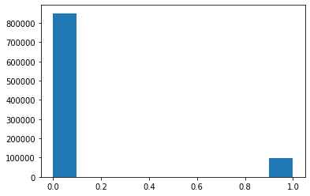

```python
#count number of patients with event 0 and event 1
plt.hist(df_patient.event)
plt.show()
```